# Long Term Experiments in ERA

Lolita Muller

2025-01-21

This chapter provides a comprehensive exploration of the ERA dataset, focusing on long-term experiments (LTEs) data. The ERA dataset compiles an extensive collection of studies, emphasizing the impact of various agricultural practices, technologies, and outcomes across diverse geographical locations and timeframes. Please send feedback on the explanations or on discoveries that should be included in the next version to Lolita Muller (m.lolita@cgiar.org).

This chapter is structured in a bookdown format, with a table of contents conveniently accessible on the right. Code snippets can be revealed by clicking the “Show” buttons.

The primary objectives of this section are:

- To explore the ERA dataset, offering insights into its structure while demonstrating the functionality and application of the ERAg package
- To visualize the ERA dataset and its LTE components, offering insights into trends and coverage.
- To demonstrate systematic mapping techniques for analyzing LTE data.
- To guide users through the implementation of meta-analyses for exploring critical agricultural research questions.

# Method

## Search

In our initial search conducted in 2014, we queried the Web of Science and Scopus databases for English-language articles focused on agricultural technology outcomes within Africa. Our search was constructed around three core components: technology, outcome, and geographic location, with an emphasis on studies specific to the African continent. The search and screening were repeated in 2019 to update the library for the years 2014 to 2018 for African countries.

Our methodology employed Boolean operators ‘OR’ and ‘AND’ to ensure the comprehensiveness of the search. This string for each technology category was run in both search engines for each of the outcome categories, ‘productivity,’ ‘resilience,’ ‘mitigation,’ and additionally for ‘barriers.’.

In 2023, we expanded the ERA dataset by updating African data from 2018 to 2023 and incorporating long-term experiment (LTE) data from South Asia. For the African update, we applied the same methodology as previous updates to ensure consistency. For the South Asia expansion on Long Term Experiments, we adhered to the established ERA criteria, focusing exclusively on published studies that met our requirements. This effort included a targeted keyword search on Google Scholar, emphasizing “long-term experiments” rather than general agricultural studies. Additionally, we conducted a thorough review of the full publication histories of relevant authors to ensure comprehensive coverage of LTEs in the region. Our work to further integrate LTEs from Asia remains ongoing.

To enhance this dataset on long term experiments, we also built upon existing resources, including the Global Long-Term Experiments Network (GLTEN) and the Guardian project. However, not all experiments could be included, as the ERA dataset is limited to LTEs with published articles that meet specific criteria. These limitations underscore the challenges in achieving complete representation.

## Screening criteria

We used a two-stage screening strategy to determine the relevance of articles to our primary research question. 1. Title and abstract screening. Our team manually screened articles titles and abstracts. 2. Full text screening. Our criteria were the following (i) location, (ii) technology and outcome relevance, (iii) data on both a new and conventional technology, and (iv) inclusion of primary data.

Articles that passed the title and abstract screening were assessed in their entirety against the same criteria as the earlier abstract and title screening. The full text screening considered all criteria listed above and focused on outcomes, comparators, and primary data, which is less commonly described in titles and abstracts.

## Search results

The initial search identified 144,567 unique articles published between 1965 and 2013, of which 1,178 were selected during the first round of screening.

In 2019, the search and screening were repeated to update the library with articles published between 2014 and 2018 for African countries. This added 972 articles to the corpus. Combining these with articles identified in previous searches resulted in the ERA library, comprising 2,011 studies published between 1965 and 2018.

In 2023, the search and screening were further updated to include studies published between 2018 and 2023. This effort added: 557 articles from Latin America, 292 articles from Africa, and 202 articles on long-term experiments (LTEs) from Africa and South Asia. As part of this update, a dedicated search for LTEs was conducted, and the extraction process for LTE-related data was refined to ensure consistency and alignment with the latest methodology, building upon the processes established in the 2019 version of the study.

| Year | Description | Articles Added |
| --- | --- | --- |
| Initial Search | First round of screening | 1178 |
| 2019 Update | Update for African countries (2014–2018) | 972 |
| 2023 Update | Update for Latin America, Africa, and LTEs (2018–2023) | 557 (Latin America), 292 (Africa), 202 (LTEs) |
| Total | Total articles in the ERA library | 3062 |

## How data were extracted

### Link to template

For each paper, data from tables, text, and figures were extracted into an Excel format. Each paper was linked to a dedicated Excel file containing detailed information on the journal, authors, location, soil characteristics, duration,experimental design, practices,treatment comparisons, crops, varieties, outcomes, and measurements and more.

[Link to excel data extraction template](https://github.com/CIAT/ERA_dev/blob/main/data_entry/industrious_elephant_2023/excel_data_extraction_template/V2.0.28%20-%20Industrious%20Elephant.xlsm)

### Link to training materials

Enumerators participated in an intensive training program spanning 4 to 6 weeks. This program was designed to equip them with the necessary skills to handle the complexities of data extraction. The training was guided by a comprehensive manual that outlined key concepts, provided examples of the types of data and experiments they would encounter, and addressed potential challenges.

To further support the learning process, the training materials included a detailed breakdown of the training sessions, practical exercises, resource documents, and instructional videos. These resources offered step-by-step guidance to ensure that extractors were well-prepared for their tasks.

Link to training materials

Following the training, ongoing support was provided through daily meetings to resolve challenges as they arose. Slack served as a platform for rapid communication and feedback, fostering collaboration among peers and project leads.

Despite these efforts, occasional errors were inevitable. To uphold data quality, the Four Eyes Principle was adopted. Each article’s extraction underwent a secondary review by another enumerator, a project lead, or both. This rigorous process ensured that errors were identified and corrected, maintaining a high standard of data accuracy and integrity.

### Link to data extracted from publications using ERA extraction templates

2020 majestic_hippo. 2022 skinny_cow 2023 industrious_elephant

## How data were imported

### ERA github

The code used to import and compile the dataset from the excel files is in the ERAg R package using R 4.2.1 (R Development Team) and may be downloaded from GitHub https://github.com/CIAT/ERA_dev. This github is under continual development.

Here are some examples of the types of functionality provided and documented:

- [Import data from excels](https://github.com/CIAT/ERA_dev/tree/main/R/import)
- [Comparison logic](https://github.com/CIAT/ERA_dev/tree/main/R/comparisons)
- [Compile data from different extraction rounds into a single simplified table](https://github.com/CIAT/ERA_dev/blob/main/R/compile/compile_datasets.R)
- [Scripts to enrich ERA data with geospatial information](https://github.com/CIAT/ERA_dev/tree/main/R/add_geodata)

## Download imported ERA data from s3 bucket

Data is available and can be downloaded from the S3 Bucket `s3://digital-atlas/era/data/` as it follows :

```r
#download most recent version of the data

# Set up connection to S3 bucket
s3<-s3fs::S3FileSystem$new(anonymous = T)
era_s3<-"s3://digital-atlas/era"

# List the files in the s3 bucket
files<-s3$dir_ls(file.path(era_s3,"data"))
# This is the most recent version of the data s3://digital-atlas/era/data/industrious_elephant_2023-YYYY-MM-DD.RData
files<-tail(grep(".RData",grep("industrious_elephant_2023",files,value=T),value=T),1)

# Create a folder to store downloaded data
download_dir<-"downloaded_data"
if(!dir.exists(download_dir)){
  dir.create(download_dir)
}

# Set a save location for the dataset (amend to something more suitable for your needs)
save_path<-file.path(getwd(),download_dir,basename(files))

if(!file.exists(save_path)){
  s3$file_download(files,save_path,overwrite = T)
}

Tables<- miceadds::load.Rdata2(file=basename(save_path),path=dirname(save_path))
```

## ERA vocabulary & meta-data

An excel workbook called era_master_sheet.xlsx is the source of truth for the controlled ERA vocabularly. One of the most useful tabs in this workbook contains the meta-data that describes the fields in the ERA tables is called ‘era_fields_v2’.

```r
    era_vocab_url<-"https://github.com/peetmate/era_codes/raw/main/era_master_sheet.xlsx"
    era_vocab_local<-file.path(getwd(),download_dir,"era_master_sheet.xlsx")

    update<-T
    if(update){
      download.file(era_vocab_url, era_vocab_local, mode = "wb")  # Download and write in binary mode
    }

  # Get names of all sheets in the workbook
  sheet_names <- readxl::excel_sheets(era_vocab_local)
  sheet_names<-sheet_names[!grepl("sheet|Sheet",sheet_names)]

  # Read each sheet into a list
  master_codes <-suppressWarnings(suppressMessages(sapply(sheet_names, FUN=function(x){data.table(readxl::read_excel(era_vocab_local, sheet = x))},USE.NAMES=T)))
```

```r
metadata<-master_codes$era_fields_v2[industrious_elephant_2023==T,.(Table,Field,Display_Name,Field_Description,Data_Type)]

# Choose table in the data model
selected_table<-"Pub.Out"

# Add an interactive selection for the table
table_choices <- metadata[, unique(Table)]
selectInput("selected_table", "Select a Table:", choices = table_choices,selected = "Pub.Out")
```

Select a Table:

```r
# Display the meta-data for the selected table
renderDT({
  DT::datatable(
    metadata[Table == input$selected_table, !"Table"], # Dynamically filter by selected table
    options = list(
      scrollY = "400px",  # Set vertical scroll height
      pageLength = 20     # Initial number of rows displayed
    )
  )
})
```

[interactive table not shown]

## Subsetting the data to LTEs

```r
# Load unique LTEs

# This data can also be loaded from the ERA_dev github
unique_ltes<-fread("https://github.com/CIAT/ERA_dev/raw/refs/heads/main/data_entry/long_term_experiments/unique.ltes.csv")

# Convert `unique_ltes` to a data.table format for efficient filtering
unique_ltes_dt <- as.data.table(unique_ltes)

#merge LTE data with the table to have all the info available

# Filter each table in `Tables` based on matching `B.Code` from `unique_ltes`
filtered_Tables <- lapply(Tables, function(tbl) {
  # Check if the table contains a `B.Code` column
  if ("B.Code" %in% colnames(tbl)) {
    # Convert the table to a data.table for efficient joins
    tbl <- as.data.table(tbl)

    # Perform a left join to retain only rows with matching `B.Code` and add `LTE.ID`
    filtered_tbl <- tbl[unique_ltes_dt, on = .(B.Code = Code), nomatch = 0,allow.cartesian=TRUE]

    # Arrange columns with `LTE.ID`, `B.Code`, `Year.start`, and `Year.end` first
    col_order <- c("LTE.ID", "B.Code", "Year.start", "Year.end",
                   setdiff(names(tbl), c("LTE.ID", "B.Code", "Year.start", "Year.end")))
    filtered_tbl <- filtered_tbl[, ..col_order]

    return(filtered_tbl)
  } else {
    return(tbl)  # Return the table unchanged if it lacks `B.Code`
  }
})
```

```r
# Display the number of unique publications and LTEs
cat("Number of unique papers:", length(unique(filtered_Tables$Pub.Out$B.Code)), "\n")
```

```
#> Number of unique papers: 211
```

```r
cat("Number of unique LTEs:", length(unique(filtered_Tables$Pub.Out$LTE.ID)), "\n")
```

```
#> Number of unique LTEs: 181
```

# Explore data

## Tables and key fields

The result is a collection of 41 tables, each containing specific information relevant to the dataset.

```r
unique_names <- names(filtered_Tables)
unique_names
```

```
#>  [1] "Pub.Out"      "Site.Out"     "Soil.Out"     "ExpD.Out"     "Times.Out"
#>  [6] "Times.Clim"   "Prod.Out"     "Var.Out"      "Till.Out"     "Plant.Out"
#> [11] "Plant.Method" "PD.Codes"     "PD.Out"       "Fert.Out"     "Fert.Method"
#> [16] "Chems.Code"   "Chems.AI"     "Chems.Out"    "Weed.Out"     "Res.Out"
#> [21] "Res.Method"   "Res.Comp"     "Har.Out"      "pH.Out"       "pH.Method"
#> [26] "Irrig.Codes"  "Irrig.Method" "WH.Out"       "AF.Out"       "AF.Trees"
#> [31] "Other.Out"    "Base.Out"     "MT.Out"       "Int.Out"      "Rot.Out"
#> [36] "Rot.Seq"      "Rot.Seq.Summ" "Rot.Levels"   "Out.Out"      "Out.Econ"
#> [41] "Data.Out"
```

The main tables are :

- Pub.Out : Publication information, DOIs, ERA version
- Site.Out : Location, coordinates
- ExpD.Out : Experimental design
- Times.Out : Timeline of the experiment
- Times.Clim : Climate information for the location
- Prod.Out : Product
- Var.Out : Variety
- Till.Out : Information on tillage during the experiment
- Plant.Out : Planting information
- PD.Out: Planting dates (Linked codes in table PD.Codes)
- Fert.Out : Information on fertilizer use during the experiment (Linked method in table Fert.Method)
- Chems.AI : Chemical active ingredients
- Chems.Out : Information on chemicals use during the experiment (Linked codes in table Chems.Codes)
- Res.Out : Information on residues during the experiment (Linked method in table Res.Method)
- Har.Out : Information on harvesting during the experiment
- pH.Out : Information on pH control during the experiment
- WH.Out : Information on water harvesting during the experiment (Irrigation information can be found in Irrig.Codes and Irrig.Method)
- AF.Out : Information on agroforestry during the experiment (Linked Tree information in table AF.Trees )
- Int.Out : Information on intercropping during the experiment
- Rot.Out : Information on crop rotation during the experiment (Linked Rotation Sequence in table Rot.Seq )
- Out.Out : Outcomes. Outcomes
- Out.Econ : Economic outcomes
- Data.Out : Measured outcomes for concerned practice and product.

The key fields used in this vignette are :

- B.Code and LTE.ID are in every table. B.Code is the code for the publication and LTE.ID is the code for the Long term experiment. several papers having different N.Codes can refer to the same long term experiment.
- Site.LatD and Site.LonD are the site’s coordinates in the Site.Out tables
- P.Product refers to the name of the crop and P.Product.Subtype is the product category in the Prod.Out table
- Out.Subind is the measured outcome in the Out.Out table

For more information on Tables and field you can explore the intro Vignette of the ERAg package -> browseVignettes(“ERAg)

# Making the systematic map of long term experiments (LTEs)

This section provides an in-depth exploration of Long Term Experiment (LTE) data, specifically focusing on data coverage, experiment durations, geographic distribution, included products, measured outcomes, and agricultural practices. Through various analyses and visualizations, we examine how LTEs contribute to understanding agricultural systems and sustainability. Key sections include:

**Data Coverage**: Overview of the number of LTEs and research publications, identifying unique experiments and papers in the dataset.

**Experiment Duration**: Analysis of LTE durations, categorized to show how long experiments have been running. This helps identify long-term trends and data richness across various timescales.

**Geographic Distribution**: Visualization of LTE locations globally, with a focus on relevant countries. We identify countries with high experiment densities, offering insights into regional research priorities.

**Products in LTEs**: Exploration of agricultural products studied across LTEs, categorized by product type. A treemap visualization provides an intuitive view of the focus areas in terms of crop and livestock products.

**Outcomes Measured**: Analysis of key outcomes tracked in LTEs, such as biodiversity, economic performance, and yield metrics. We look at the prevalence of each outcome across experiments and use bar charts to illustrate these trends.

**Agricultural Practices**: Investigation of the practices implemented in LTEs, such as rotation, intercropping, and fertilization methods. This section also identifies LTEs that integrate both improved and unimproved crop varieties, as well as different fertilization techniques.

**Practice Bundles**: Analyzing common bundles of practices used in LTEs. An UpSet plot visualizes the overlap of practices across LTEs, highlighting which practices are commonly applied together.

## Data Coverage

```r
pub_no<-filtered_Tables$Pub.Out[,length(unique(B.Code))]

lte_no<-filtered_Tables$Pub.Out[,length(unique(LTE.ID))]

country_no<-filtered_Tables$Site.Out[,length(unique(Country))]

site_no<-filtered_Tables$Site.Out[,length(unique(Site.ID))]

observation_no<-filtered_Tables$Data.Out[,.N]

obs_average<-filtered_Tables$Data.Out[,.(N=.N),by=.(LTE.ID,Site.ID)][,round(mean(N),0)]

duration_average<-filtered_Tables$Data.Out[,.(duration=max(Exp.Duration,na.rm=T)),.(B.Code,LTE.ID)][,round(mean(duration,na.rm=T),1)]
```

The dataset of 34815 individual outcomes includes a total of 181 long-term experiments (LTEs) derived from 211 unique publications. These come from 260 sites in 28 countries. The average number of observations per study is 99 and the average duration of LTEs is 13.5 years.

## Duration of LTEs

To effectively visualize the duration of LTES, we grouped them into categorized duration ranges. This approach helps organize the experiments into manageable categories, allowing us to create a clear and easily interpretable plot, especially given the large volume of papers in our dataset.

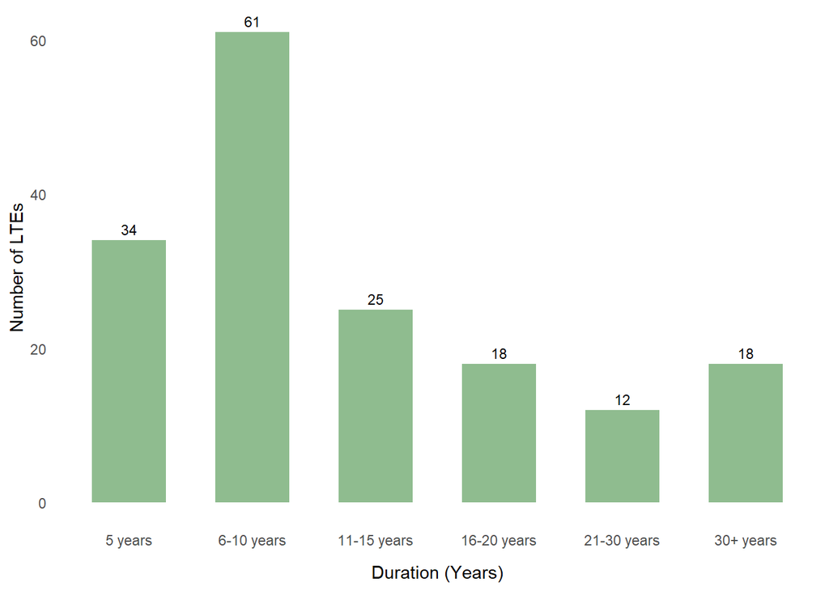

```r
# Table with time data
times_out <- filtered_Tables$Times.Out

# Ensure the data is unique by LTE.ID, Year.start, and Year.end
times_out_unique <- times_out %>%
  dplyr::select(LTE.ID, Year.start, Year.end) %>%
  dplyr::distinct() %>%
  dplyr::arrange(LTE.ID, Year.start)

# Create a new column for duration (years)
times_out_unique <- times_out_unique %>%
  mutate(
    LTE_ID = LTE.ID,  # Standardize to LTE_ID to use consistently
    Year.start = as.numeric(Year.start),
    Year.end = as.numeric(Year.end),
    Duration = Year.end - Year.start
  ) %>%
  group_by(LTE_ID) %>%
  filter(Duration == max(Duration, na.rm = TRUE)) %>%
  ungroup() %>%
  mutate(Duration_Category = case_when(
    Duration <= 5 ~ "5 years",
    Duration > 5 & Duration <= 10 ~ "6-10 years",
    Duration > 10 & Duration <= 15 ~ "11-15 years",
    Duration > 15 & Duration <= 20 ~ "16-20 years",
    Duration > 20 & Duration <= 30 ~ "21-30 years",
    Duration > 30 ~ "30+ years"
  )) %>%
  filter(!is.na(Duration)) %>%
  dplyr::select(LTE_ID, Year.start, Year.end, Duration, Duration_Category)



# Count the number of LTEs in each duration category
times_out_unique$Duration_Category <- factor(times_out_unique$Duration_Category,
                                             levels = c("5 years", "6-10 years", "11-15 years",
                                                        "16-20 years", "21-30 years", "30+ years"))

# Count the number of LTEs in each duration category
duration_counts <- times_out_unique %>%
  group_by(Duration_Category) %>%
  summarise(count = n()) %>%
  arrange(Duration_Category)

# Plot the bar chart with ordered categories
options(repr.plot.width = 16, repr.plot.height = 8)  # Set larger dimensions

duration_plot <- ggplot(duration_counts, aes(x = Duration_Category, y = count)) +
  geom_bar(stat = "identity", fill = "darkseagreen", width = 0.6) +  # Adjust bar width
  geom_text(aes(label = count), vjust = -0.5, color = "black", size = 3) +  # Add count labels on top of each bar
  labs( x = "Duration (Years)",
       y = "Number of LTEs") +
  theme_minimal() +
  theme(
    panel.grid = element_blank(),  # Remove grid lines
    axis.title.x = element_text(margin = margin(t = 10))  # Move x-axis title down
  )

print(duration_plot)
```

## Geographic Distribution of LTEs

Long Term Experiment data was collected for Africa and South Asia, with each experiment linked to a specific location through its coordinates, enabling precise mapping of the data.

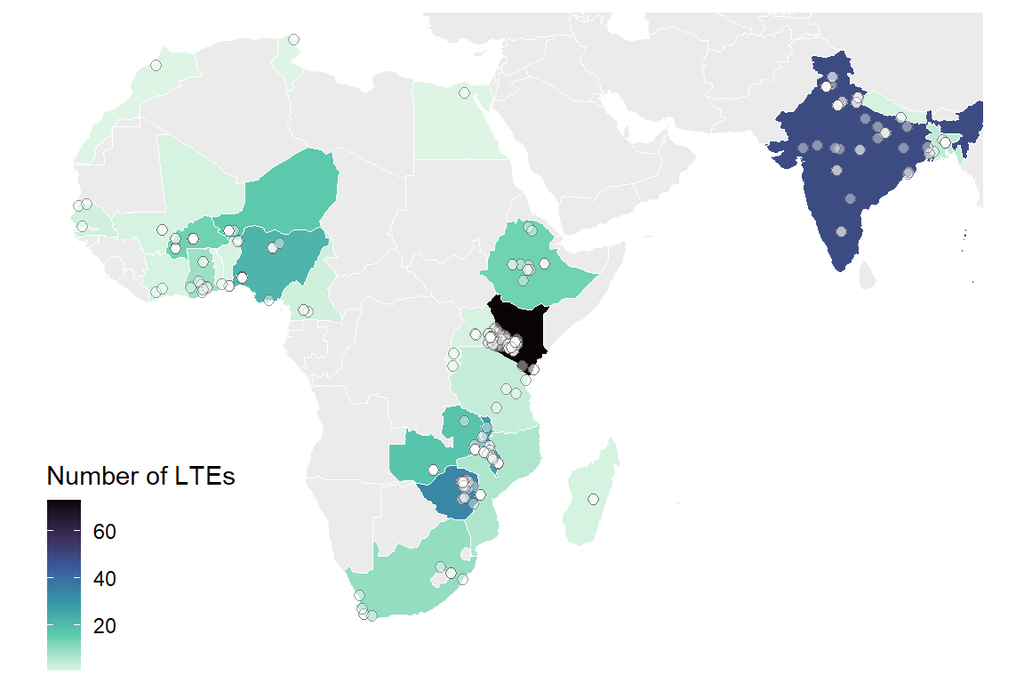

```r
# Extract and clean Site data from filtered_Tables
site_data <- as.data.frame(filtered_Tables$Site.Out) %>%
  dplyr::select(LTE.ID, Country, Latitude = Site.LatD, Longitude = Site.LonD) %>%
  distinct() %>%
  mutate(
    Longitude = as.numeric(Longitude),
    Latitude = as.numeric(Latitude)
  ) %>%
  filter(!is.na(Longitude) & !is.na(Latitude))  # Remove rows with missing coordinates


# Count the number of LTEs per country
lte_counts <- site_data %>%
  group_by(Country) %>%
  summarise(N_LTE = n())

# Prepare the world map, excluding specified regions
world <- ne_countries(scale = "medium", returnclass = "sf") %>%
  filter(!continent %in% c("North America", "South America", "Europe", "Oceania", "Antarctica") &
           !admin %in% c("Russia")) %>%
  mutate(admin = if_else(admin == "United Republic of Tanzania", "Tanzania", admin))

# Ensure the CRS of `world` is consistent (EPSG:4326)
world <- st_transform(world, crs = 4326)

# Filter site data to exclude the specified regions
site_data_filtered <- site_data %>%
  st_as_sf(coords = c("Longitude", "Latitude"), crs = 4326, remove = FALSE)

# Join LTE counts with country geometries for mapping
countries_studies <- world %>%
  dplyr::select(admin, geometry) %>%
  rename(Country = admin) %>%
  left_join(lte_counts, by = "Country")

# Plot the map with LTE counts per country
map <- ggplot() +
  geom_sf(data = countries_studies, aes(fill = N_LTE), color = "white") +
  geom_point(data = site_data_filtered, aes(x = Longitude, y = Latitude),
             shape = 21, color = "black", fill = "white", size = 2, alpha = 0.4) +
  scale_fill_viridis_c(
    option = "mako",
    direction = -1,
    na.value = "gray92"  # Set color for NA values
  ) +
  labs(fill = "Number of LTEs") +
  theme_minimal() +
  theme(
    legend.key.size = unit(1, "lines"),
    axis.line = element_blank(),
    axis.text = element_blank(),
    axis.ticks = element_blank(),
    axis.title.x = element_blank(),
    axis.title.y = element_blank(),
    panel.grid.major = element_blank(),
    panel.grid.minor = element_blank(),
    legend.position = c(0.1, 0.15)
  ) +
  coord_sf(xlim = c(-20, 95), ylim = c(-40, 40), expand = FALSE)

# Display the plot
map
```

```r
# Display the summary table of LTE counts by country
DT::datatable(
  lte_counts,
  options = list(
    scrollY = "400px",  # Set vertical scroll height
    pageLength = 20     # Initial number of rows displayed
  )
)
```

|  | Country | N_LTE |
| --- | --- | --- |
| 1 | Bangladesh | 5 |
| 2 | Benin | 2 |
| 3 | Burkina Faso | 14 |
| 4 | Burundi | 1 |
| 5 | Cameroon | 3 |
| 6 | Egypt | 1 |
| 7 | Ethiopia | 14 |
| 8 | Ghana | 9 |
| 9 | India | 49 |
| 10 | Ivory Coast | 2 |

[output cut: 18 more lines]

```r
# Optionally save the summary table as a CSV
# write.csv(lte_counts, "summary_by_country.csv", row.names = FALSE)
```

## Types of Products Studied in LTEs

The products in the dataset are organized hierarchically, with each product labeled by its common or latin name and grouped into broader categories such as cereals, legumes, etc. It’s important to note that a single paper can study multiple products, which means the total number of papers represented in the treemaps exceeds the actual total number of unique papers.

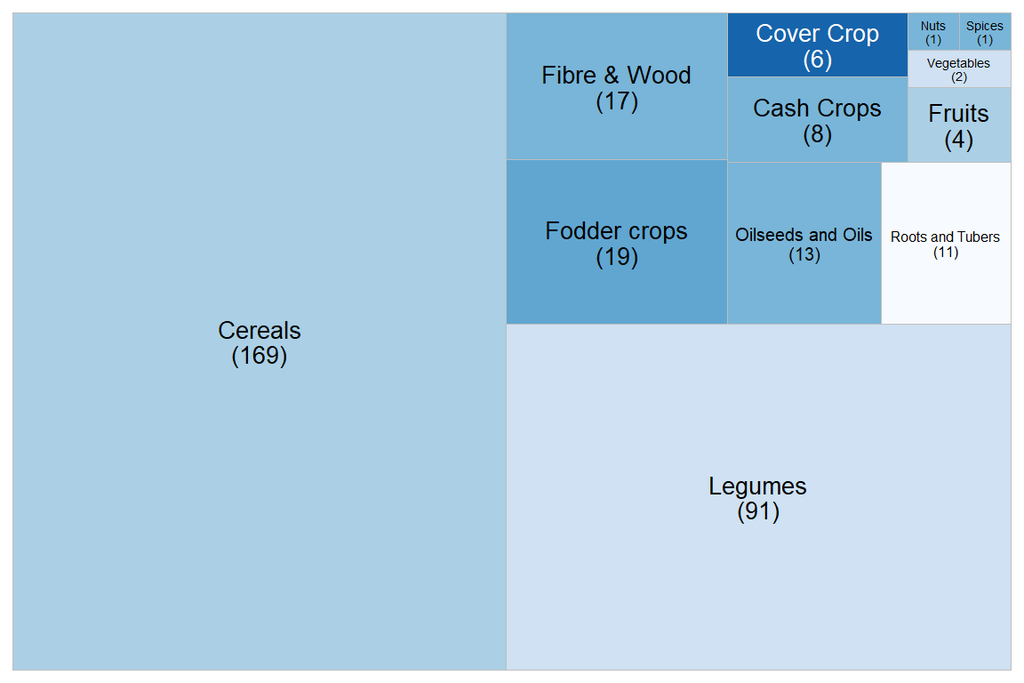

```r
# Prepare the data from filtered_Tables$Prod.Out
DATA_split_product <- filtered_Tables$Prod.Out %>%
  dplyr::select(LTE.ID, P.Product.Subtype, B.Code) %>%
  distinct() %>%  # Remove duplicates
  filter(P.Product.Subtype != "Energy Production", P.Product.Subtype != "Bovine", P.Product.Subtype != "Caprine") %>%
  separate_rows(P.Product.Subtype, sep = "-") %>%  # Split multiple product subtypes if necessary
  group_by(P.Product.Subtype, LTE.ID) %>%
  summarize(N_Studies = n_distinct(B.Code)) %>%  # Count distinct studies per subtype and LTE.ID
  group_by(P.Product.Subtype) %>%
  summarize(N_LTE = n_distinct(LTE.ID), N_Studies = sum(N_Studies), .groups = 'drop')%>%
 mutate(P.Product.Subtype = case_when(
    P.Product.Subtype %in% c("Bovine") ~ "Cattle",
    P.Product.Subtype %in% c("Caprine") ~ "Shoats",
    P.Product.Subtype %in% c("Fodders") ~ "Fodder crops",
    P.Product.Subtype %in% c("Starchy Staples") ~ "Roots and Tubers",
    TRUE ~ P.Product.Subtype)) # Sum up LTEs and studies per subtype

# Calculating relative abundance of each Product and taking out Trees and Fallow products that don't have relevance here

DATA_product <- DATA_split_product %>%
  rename(Category = P.Product.Subtype) %>%
  mutate(Relative_Abundance = (N_LTE / sum(N_LTE))) %>%
  filter(Category!="Fallow",
         Category!="Tree")

# Custom colors for the categories
custom_colors <- c(
  "Cover Crop" = "#1664AB",
  "Fallow" = "#1664AB",
  "Cash Crops" = "#78B5D8",
  "Cereals" = "#ABCFE5",
  "Fibre & Wood" = "#78B5D8",
  "Fodder crops" = "#60A6D1",
  "Fruits" = "#ABCFE5",
  "Nuts" = "#78B5D8",
  "Spices" = "#78B5D8",
  "Legumes" = "#CFE1F2",
  "Oilseeds and Oils" = "#78B5D8",
  "Tree" = "#4A97C9",
  "Roots and Tubers" = "#F7FBFF",
  "Vegetables" = "#CFE1F2"
)

# Function to calculate luminance of a color
calculate_luminance <- function(color) {
  cols <- col2rgb(color) / 255
  (0.299 * cols[1, ] + 0.587 * cols[2, ] + 0.114 * cols[3, ])
}

# Function to determine text color based on background luminance
text_color <- function(bg_color) {
  if (calculate_luminance(bg_color) < 0.5) "white" else "black"
}

# Add a column for text color based on category color
DATA_product <- DATA_product %>%
  mutate(text_color = sapply(Category, function(cat) text_color(custom_colors[cat])))

# Create the treemap plot
treemap <- ggplot(DATA_product, aes(area = N_LTE, fill = Category, label = ifelse(Category == "Porcine", "", paste0(Category, "\n", "(", N_LTE, ")")))) +
  geom_treemap() +
  geom_treemap_text(aes(colour = text_color), place = "center", size = 10) +
  scale_fill_manual(values = custom_colors, guide = FALSE) +  # Use custom colors
  scale_color_identity() +  # Apply the custom text colors
  theme(
    text = element_text(family = "Arial", face = "italic", size = 8),
    panel.background = element_rect(fill = "white")
  )

# Display the plot
treemap
```

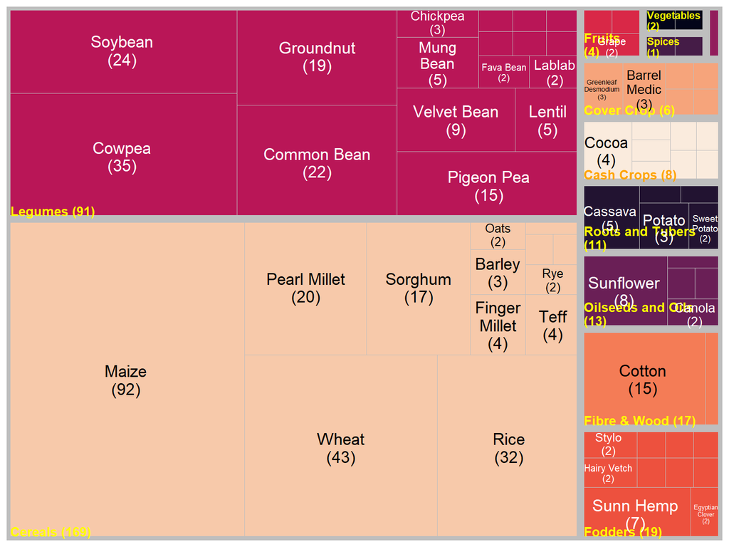

```r
DATA_split_product <- filtered_Tables$Prod.Out %>%
  dplyr::select(LTE.ID, P.Product.Subtype, P.Product, B.Code) %>%
  distinct() %>%
  filter(P.Product.Subtype != "Energy Production",
         P.Product.Subtype != "Bovine",
         P.Product.Subtype != "Caprine") %>%
  separate_rows(P.Product.Subtype, sep = "-") %>%
  group_by(P.Product.Subtype, P.Product, LTE.ID) %>%
  summarize(N_Studies = n_distinct(B.Code), .groups = 'drop') %>%
  group_by(P.Product.Subtype, P.Product) %>%
  summarize(N_LTE = n_distinct(LTE.ID), N_Studies = sum(N_Studies), .groups = 'drop')

calculate_luminance <- function(color) {
  cols <- col2rgb(color) / 255
  (0.299 * cols[1, ] + 0.587 * cols[2, ] + 0.114 * cols[3, ])
}

text_color <- function(bg_color) {
  if (calculate_luminance(bg_color) < 0.5) "white" else "black"
}

# Step 3: Set up color palette and ensure it matches unique categories
distinct_colors <- viridis_pal(option = "F", direction = -1)(length(unique(DATA_split_product$Category)))  # 14 colors in reverse viridis palette
names(distinct_colors) <- unique(DATA_split_product$Category)

DATA_product <- DATA_split_product %>%
  rename(Category = P.Product.Subtype, Subcategory = P.Product) %>%
  mutate(Relative_Abundance = (N_LTE / sum(N_LTE)),
         text_color = sapply(Category, function(cat) text_color(distinct_colors[cat]))) %>%
  filter(Category!="Fallow",
         Category!="Tree") %>%
mutate(Category = case_when(
    Category %in% c("Bovine") ~ "Cattle",
    Category %in% c("Caprine") ~ "Shoats",
    Category %in% c("Starchy Staples") ~ "Roots and Tubers",
    TRUE ~ Category
  )) %>%
  filter(Category!="Fallow",
         Category!="Tree")

category_sum <- filtered_Tables$Prod.Out %>%
  dplyr::select(LTE.ID, P.Product.Subtype, B.Code) %>%
  distinct() %>%  # Remove duplicates
  filter(P.Product.Subtype != "Energy Production", P.Product.Subtype != "Bovine", P.Product.Subtype != "Caprine") %>%
  separate_rows(P.Product.Subtype, sep = "-") %>%  # Split multiple product subtypes if necessary
  group_by(P.Product.Subtype, LTE.ID) %>%
  summarize(N_Studies = n_distinct(B.Code)) %>%  # Count distinct studies per subtype and LTE.ID
  group_by(P.Product.Subtype) %>%
  summarize(N_LTE = n_distinct(LTE.ID), N_Studies = sum(N_Studies), .groups = 'drop') %>%
  mutate(P.Product.Subtype = case_when(
    P.Product.Subtype %in% c("Bovine") ~ "Cattle",
    P.Product.Subtype %in% c("Caprine") ~ "Shoats",
    P.Product.Subtype %in% c("Starchy Staples") ~ "Roots and Tubers",
    TRUE ~ P.Product.Subtype
  )) %>%
  rename(Category = P.Product.Subtype)  # Rename for joining

# Merge category sums into DATA_product
DATA_product <- DATA_product %>%
  left_join(category_sum %>% group_by(Category) %>% summarize(category_sum = sum(N_LTE)), by = "Category") %>%
  mutate(Category_Label = paste0(Category, " (", category_sum, ")"))

# Step 3: Set up color palette and ensure it matches unique categories
distinct_colors <- viridis_pal(option = "F", direction = -1)(length(unique(DATA_product$Category)))  # 14 colors in reverse viridis palette
names(distinct_colors) <- unique(DATA_product$Category)

# Step 4: Define luminance functions for text color
calculate_luminance <- function(color) {
  cols <- col2rgb(color) / 255
  (0.299 * cols[1, ] + 0.587 * cols[2, ] + 0.114 * cols[3, ])
}

text_color <- function(bg_color) {
  if (calculate_luminance(bg_color) < 0.5) "white" else "black"
}

# Step 5: Apply text color based on background color
DATA_product <- DATA_product %>%
  mutate(text_color = sapply(Category, function(cat) text_color(distinct_colors[cat])))


DATA_product$Subcategory <- gsub("Stylosanthes guianensis", "Stylo", DATA_product$Subcategory)
DATA_product$Subcategory <- gsub("Desmodium intortum", "Greenleaf Desmodium", DATA_product$Subcategory)
DATA_product$Subcategory <- gsub("Medicago truncatula", "Barrel Medic", DATA_product$Subcategory)


treemap <- ggplot(DATA_product, aes(area = N_LTE, fill = Category,
                                   subgroup = Category_Label,  # Grouping by main Category
                                   label = ifelse(N_LTE == 1, "", paste0(Subcategory, "\n", "(", N_LTE, ")")))) +
  geom_treemap() +
  geom_treemap_subgroup_border(color = "grey", size = 8) +  # Thicker border for each Category
  geom_treemap_subgroup_text(aes(label = Category_Label,
                                 color = ifelse(Category == "Cash Crops", "orange", "yellow")),
                             place = "bottomleft", grow = FALSE, reflow = TRUE,
                             fontface = "bold", size = 10, min.size = 4) +  # Category names in orange for Cash Crops, yellow otherwise
  geom_treemap_text(aes(label = ifelse(N_LTE == 1, "", paste0(Subcategory, "\n", "(", N_LTE, ")")),
                        color = text_color),
                    place = "center", grow = FALSE, reflow = TRUE, size = 13) +  # Product names and counts
  scale_fill_manual(values = distinct_colors, guide = "none") +  # Apply colors
  scale_color_identity() +
  theme(
    text = element_text(family = "Arial", size = 8),
    panel.background = element_rect(fill = "white")
  )

treemap
```

Some cells of the figure are to small for the product names to appear. In order to have a full view of the number of studies for each table you can also display a table.

```r
DT::datatable(
  DATA_split_product,
  options = list(
    scrollY = "400px",  # Set vertical scroll height
    pageLength = 20     # Initial number of rows displayed
  )
)
```

|  | P.Product.Subtype | P.Product | N_LTE | N_Studies |
| --- | --- | --- | --- | --- |
| 1 | Cash Crops | Cocoa | 4 | 4 |
| 2 | Cash Crops | Coffee | 1 | 1 |
| 3 | Cash Crops | Guar Gum | 1 | 1 |
| 4 | Cash Crops | Robusta | 1 | 1 |
| 5 | Cash Crops | Rubber | 1 | 1 |
| 6 | Cash Crops | Sugar Cane | 1 | 2 |
| 7 | Cash Crops | Tea | 1 | 2 |
| 8 | Cash Crops | Tree cassava | 1 | 1 |
| 9 | Cereals | Barley | 3 | 3 |
| 10 | Cereals | Black oats | 1 | 4 |

[output cut: 106 more lines]

## Commonly Measured Outcomes in LTEs

The outcomes in the dataset are structured similarly to the way crops are categorized. Subindicators represent the specific outcomes measured in the studies, such as soil organic carbon or product yield. These are grouped into broader categories called indicators, which encompass related themes (e.g., “Soil Quality” and “Product Yield”). Indicators are then organized into even larger categories called subpillars, which capture overarching aspects like physical yield or economics. Finally, the subpillars are grouped into three main pillars: resilience, productivity, and mitigation, representing the highest-level categories for analysis.

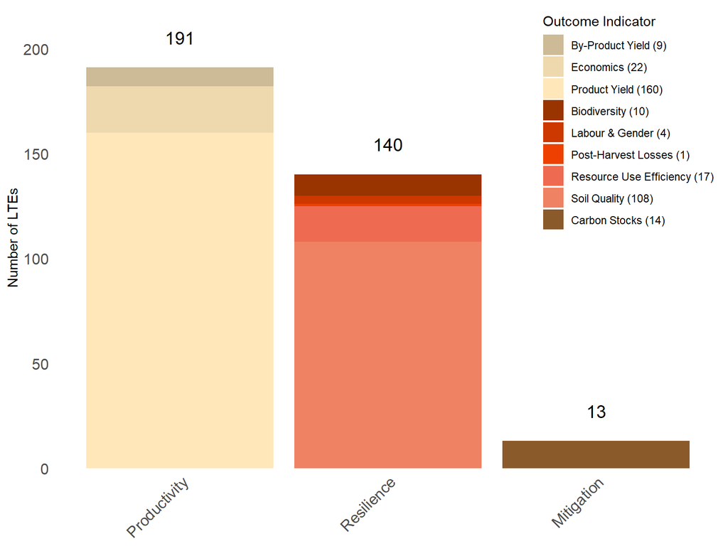

```r
# Load and process the master sheet data
era_master_sheet_out_ <- master_codes$out

# Merge and process outcome data with hierarchical structure
DATA_OUTCOMES <- filtered_Tables$Out.Out %>%
  left_join(era_master_sheet_out_, by = c("Out.Subind" = "Subindicator")) %>%
  dplyr::select(LTE.ID, B.Code, Pillar, Subpillar, Indicator, Out.Subind) %>%
  distinct() %>%
  mutate(Indicator = case_when(
    Indicator %in% c("Labour", "Gender Equity") ~ "Labour & Gender",
    Indicator == "Efficiency" ~ "Resource Use Efficiency",
    Indicator == "Pest & Pathogen" ~ "Post-Harvest Losses",
    Indicator %in% c("Economic Performance", "Costs", "Income") ~ "Economics",
    Indicator == "Non-Product Yield" ~ "By-Product Yield",
    TRUE ~ Indicator
  )) %>%
  group_by(Pillar, Subpillar, Indicator, LTE.ID) %>%
  summarize(N_Studies = n_distinct(B.Code), .groups = 'drop') %>%
  group_by(Pillar, Subpillar, Indicator) %>%
  summarize(N_Studies = sum(N_Studies), N_LTE = n_distinct(LTE.ID), .groups = 'drop') %>%
  mutate(Pillar = factor(Pillar, levels = c("Productivity", "Resilience", "Mitigation")))

# Define custom colors and legend
category_colors <- c(
  "Biodiversity" = "#993300",
  "By-Product Yield" = "wheat3",
  "Carbon Stocks" = "tan4",
  "Economics" = "wheat2",
  "Labour & Gender" = "orangered3",
  "Post-Harvest Losses" = "orangered2",
  "Product Yield" = "wheat1",
  "Resource Use Efficiency" = "coral2",
  "Soil Quality" = "salmon2"
)
custom_legend_order <- c("By-Product Yield", "Economics", "Product Yield", "Biodiversity",
                         "Labour & Gender", "Post-Harvest Losses", "Resource Use Efficiency",
                         "Soil Quality", "Carbon Stocks")
custom_studies_order <- c(9, 22, 160, 10, 4, 1, 17, 108, 14)

# Compute total LTEs for each pillar
totals_heights <- DATA_OUTCOMES %>%
  group_by(Pillar) %>%
  summarize(total_N_LTE = sum(N_LTE), height_for_total = total_N_LTE + 10)

# Create the plot
outcomes <- ggplot(DATA_OUTCOMES, aes(x = Pillar, y = N_LTE, fill = Indicator)) +
  geom_col(width = 0.9) +
  geom_text(data = totals_heights, aes(x = Pillar, y = height_for_total, label = total_N_LTE),
            inherit.aes = FALSE, size = 5, vjust = -0.2) +
  labs(x = NULL, y = "Number of LTEs") +
  scale_fill_manual(
    values = category_colors,
    breaks = custom_legend_order,
    labels = paste(custom_legend_order, " (", custom_studies_order, ")", sep = "")
  ) +
  scale_y_continuous(limits = c(0, 220), expand = c(0, 0)) +
  theme_minimal() +
  theme(
    axis.text.x = element_text(size = 12, angle = 45, hjust = 1),
    axis.line.y = element_blank(),
    axis.text.y = element_text(size = 12),
    axis.ticks.y = element_blank(),
    panel.grid.major = element_blank(),
    panel.grid.minor = element_blank(),
    panel.border = element_blank(),
    legend.position = c(1, 1),
    legend.justification = c(1, 1),
    legend.box = "vertical"
  ) +
  labs(fill = "Outcome Indicator")

# Display the plot
print(outcomes)
```

Some Long-Term Experiments (LTEs) measure multiple outcomes within a single experiment. Although we have data for 181 LTEs, the total counts in our analysis may exceed this number. This is because a single LTE can assess multiple outcomes, such as both by-product yield and product yield, resulting in the experiment being counted for each outcome it measures. To provide a clearer and more intuitive visualization, we can unstack the bars in the graph to differentiate between overlapping measurements.

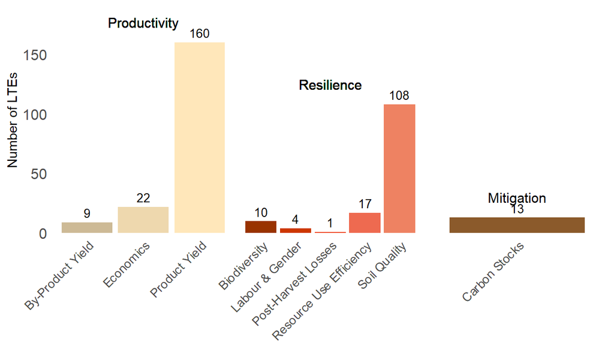

```r
# Determine maximum y values and custom x positions for each Pillar
max_values <- DATA_OUTCOMES %>%
  group_by(Pillar) %>%
  summarize(
    max_y = max(N_LTE) + 17,  # Adjust spacing above the bar
    x_position = case_when(
      Pillar == "Productivity" ~ 2,
      Pillar == "Resilience" ~ 3,
      Pillar == "Mitigation" ~ 1
    )
  )

# Create faceted plot with annotations
disagregated_outcome <- ggplot(DATA_OUTCOMES, aes(x = Indicator, y = N_LTE, fill = Indicator)) +
  geom_col(width = 0.9) +
  labs(x = NULL, y = "Number of LTEs") +
  scale_fill_manual(
    values = category_colors,
    breaks = custom_legend_order,
    labels = paste(custom_legend_order, " (", custom_studies_order, ")", sep = "")
  ) +
  scale_y_continuous(limits = c(0, 190), expand = c(0, 0)) +
  facet_wrap(~Pillar, scales = "free_x") +
  theme_minimal() +
  theme(
    axis.text.x = element_text(size = 10, angle = 45, hjust = 1),
    axis.line.y = element_blank(),
    axis.text.y = element_text(size = 12),
    axis.ticks.y = element_blank(),
    panel.grid.major = element_blank(),
    panel.grid.minor = element_blank(),
    panel.border = element_blank(),
    strip.text = element_blank(),
    legend.position = "none"
  ) +
  labs(fill = "Outcome Indicator") +

  # Add count labels on top of each bar
  geom_text(
    aes(label = N_LTE),
    vjust = -0.5,
    size = 3.5
  ) +

  # Add pillar labels with custom x positions
  geom_text(
    data = max_values,
    aes(x = x_position, y = max_y, label = Pillar),
    inherit.aes = FALSE,
    size = 4
  )

# Display the plot
print(disagregated_outcome)
```

A valuable analysis is examining which outcomes are commonly studied together in long-term experiments. An UpSet plot can effectively visualize these outcomes combinations, revealing patterns of co-studied outcomes across LTEs.

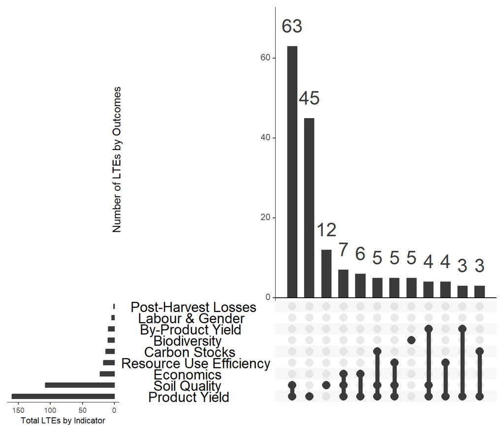

```r
# Step 2: Merge and process outcome data with hierarchical structure
DATA_OUTCOMES <- filtered_Tables$Out.Out %>%
  left_join(era_master_sheet_out_, by = c("Out.Subind" = "Subindicator")) %>%
  dplyr::select(LTE.ID, B.Code, Pillar, Subpillar, Indicator, Out.Subind) %>%
  distinct() %>%
  mutate(Indicator = case_when(
    Indicator %in% c("Labour", "Gender Equity") ~ "Labour & Gender",
    Indicator == "Efficiency" ~ "Resource Use Efficiency",
    Indicator == "Pest & Pathogen" ~ "Post-Harvest Losses",
    Indicator %in% c("Economic Performance", "Costs", "Income") ~ "Economics",
    Indicator == "Non-Product Yield" ~ "By-Product Yield",
    TRUE ~ Indicator
  ))

DATA_OUTCOMES<-DATA_OUTCOMES%>%
  dplyr::select(LTE.ID,Pillar, Subpillar, Indicator)%>%
  distinct()

# Step 3: Create list of indicators for each LTE.ID
indicator_list <- DATA_OUTCOMES %>%
  group_by(LTE.ID) %>%
  summarise(Indicators = list(unique(Indicator))) %>%
  pull(Indicators)

# Step 4: Prepare data for UpSet plot
# Convert the list of indicators into a format compatible with UpSetR's fromList function
indicator_list_named <- list()
for (ind in unique(DATA_OUTCOMES$Indicator)) {
  indicator_list_named[[ind]] <- DATA_OUTCOMES %>%
    filter(Indicator == ind) %>%
    distinct(LTE.ID) %>%
    pull(LTE.ID)
}

# Step 5: Generate the UpSet plot
upset_plot_outcome <- upset(
  fromList(indicator_list_named),
  order.by = c("degree", "freq"),        # Order intersections by degree and then by frequency
  decreasing = c(TRUE, TRUE),            # Sort both degree and frequency in descending order
  nsets = length(indicator_list_named),  # Display all indicators in set size bars
  nintersects = 12,                      # Show all intersections and let the order be controlled by degree and freq
  keep.order = FALSE,                    # Automatically order sets by size unless specified
  sets = names(indicator_list_named),
  mainbar.y.label = "Number of LTEs by Outcomes",
  sets.x.label = "Total LTEs by Indicator",
  point.size = 3.5,
  line.size = 2,
  text.scale = c(1.3, 1.3, 1, 1, 2, 3)
)


# Plot the UpSet graph
print(upset_plot_outcome)
```

Key Components of an UpSet Plot :

- The bar chart at the top represents the size of the intersections between the measured outcomes. Each bar corresponds to a specific combination of outcomes
- Intersection Matrix (Bottom):The grid-like matrix below the bar chart shows which sets are included in each intersection.
- Set Size Bar Chart (Side): A vertical bar chart on the side shows the total size of each individual set. This helps you understand the overall size of each set before examining intersections.

## Analyzing Practice Combinations in LTEs

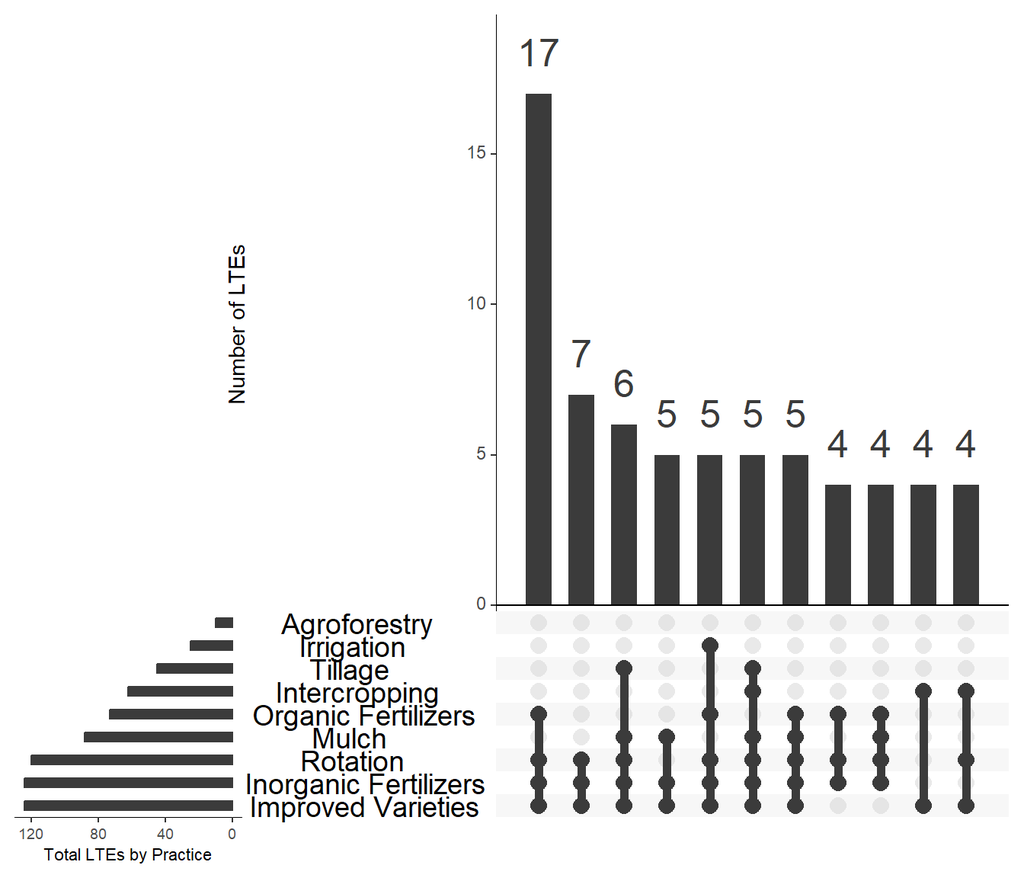

```r
# Create a function to count LTEs for each practice and pull LTE IDs
count_and_pull_lte <- function(data, column = "LTE.ID") {
  lte_ids <- data %>%
    distinct(!!sym(column)) %>%
    pull(!!sym(column))

  lte_count <- length(lte_ids)

  list(count = lte_count, ids = lte_ids)
}

# Calculate LTE counts for each practice and pull corresponding LTE IDs
rotation <- count_and_pull_lte(filtered_Tables$Rot.Out)
intercropping <- count_and_pull_lte(filtered_Tables$Int.Out)
irrigation <- count_and_pull_lte(filtered_Tables$Irrig.Method)
mulch <- count_and_pull_lte(filtered_Tables$Res.Method)
agroforestry <- count_and_pull_lte(filtered_Tables$AF.Out)

tillage <- filtered_Tables$MT.Out %>%
  filter(grepl("No or Zero Tillage", Till.Practice)) %>%
  distinct(LTE.ID) %>%
  pull(LTE.ID)

tillage_count <- length(tillage)




# Count LTEs with only "Improved" varieties
improved_var_lte <- filtered_Tables$Var.Out %>%
  filter(grepl("Improved", V.Crop.Practice)) %>%
  distinct(LTE.ID) %>%
  pull(LTE.ID)

improved_only_count <- length(improved_var_lte)



# Count LTEs with organic fertilizers (excluding specific categories)
organic_lte <- filtered_Tables$Fert.Method %>%
  filter(
    !grepl("Inorganic", F.Category) &
    !grepl("MicroNutrient", F.Category) &
    !grepl("Unspecified", F.Category)
  ) %>%
  distinct(LTE.ID) %>%
  pull(LTE.ID)

organic_count <- length(organic_lte)

# Identify LTEs comparing different levels of inorganic fertilizer
inorganic_levels_LTEs <- filtered_Tables$Fert.Method %>%
  filter(grepl("Inorganic", F.Category)) %>%
  group_by(LTE.ID) %>%
  summarise(level_count = n_distinct(F.Level.Name)) %>%
  filter(level_count > 1) %>%
  pull(LTE.ID)

inorganic_levels_count <- length(inorganic_levels_LTEs)



# Deduce the overlap from others
inorganic_levels_count <- length(inorganic_levels_LTEs)

# Summarize the LTE counts for each practice
lte_summary <- tibble(
  Practice = c(
    "Rotation", "Intercropping", "Irrigation", "Tillage", "Mulch", "Agroforestry", "Improved Varieties","Organic Fertilizers", "Inorganic Fertilizers"
  ),
  LTE_Count = c(
    rotation$count, intercropping$count, irrigation$count, tillage_count, mulch$count,
    agroforestry$count, improved_only_count,
    organic_count, inorganic_levels_count
  )
)

# Step 2: Create a list of solo practices with corresponding LTE IDs
solo_practice_list <- list(
  Rotation = rotation$ids,
  Intercropping = intercropping$ids,
  Irrigation = irrigation$ids,
  Tillage = tillage,
  Mulch = mulch$ids,
  Agroforestry = agroforestry$ids,
  "Improved Varieties" = improved_var_lte,
  "Organic Fertilizers" = organic_lte,
  "Inorganic Fertilizers" = inorganic_levels_LTEs
)

# Step 3: Convert the practice list to a combination matrix and create the UpSet plot
upset_plot_prac<- upset(
  fromList(solo_practice_list),
  order.by = "freq",
  nsets = length(solo_practice_list), # Use all solo practices as set size bars
  nintersects = 11, # Show all intersections
  keep.order = FALSE, # Maintain the order of sets as they appear in set_list
  sets = names(solo_practice_list), # All solo practices have set size bars
  mainbar.y.label = "Number of LTEs",
  sets.x.label = "Total LTEs by Practice",
  point.size = 3.5,
  line.size = 2,
  text.scale = c(1.3, 1.3, 1, 1, 2, 3)
)

# Plot the UpSet graph
print(upset_plot_prac)
```

```r
#ggsave("upset.png", upset_plot, width = 15, height = 10, dpi = 500)
```

## Additional Information by Country and Practice

```r
combined_summary <- site_data %>%
  dplyr::select(LTE.ID, Country) %>%
  distinct() %>%
  left_join(
    bind_rows(
      filtered_Tables$Rot.Out %>% mutate(Practice = "Rotation") %>% dplyr::select(LTE.ID, Practice),
      filtered_Tables$Int.Out %>% mutate(Practice = "Intercropping") %>% dplyr::select(LTE.ID, Practice),
      filtered_Tables$Irrig.Method %>% mutate(Practice = "Irrigation") %>% dplyr::select(LTE.ID, Practice),
      filtered_Tables$Till.Out %>% mutate(Practice = "Tillage") %>% dplyr::select(LTE.ID, Practice),
      filtered_Tables$Res.Method %>% mutate(Practice = "Mulch") %>% dplyr::select(LTE.ID, Practice),
      filtered_Tables$AF.Out %>% mutate(Practice = "Agroforestry") %>% dplyr::select(LTE.ID, Practice),
      filtered_Tables$Var.Out %>% filter(grepl("Improved", V.Crop.Practice) & grepl("Unimproved", V.Crop.Practice)) %>% mutate(Practice = "Improved and Unimproved Varieties") %>% dplyr::select(LTE.ID, Practice),
      filtered_Tables$Var.Out %>% filter(grepl("Improved", V.Crop.Practice)) %>% mutate(Practice = "Improved Varieties") %>% dplyr::select(LTE.ID, Practice),
      filtered_Tables$Var.Out %>% filter(grepl("Unimproved", V.Crop.Practice)) %>% mutate(Practice = "Unimproved Varieties") %>% dplyr::select(LTE.ID, Practice),
      filtered_Tables$Fert.Method %>% filter(grepl("Inorganic", F.Category)) %>% mutate(Practice = "Inorganic Fertilizer") %>% dplyr::select(LTE.ID, Practice),
      filtered_Tables$Fert.Method %>% filter(!grepl("Inorganic|MicroNutrient|Unspecified", F.Category)) %>% mutate(Practice = "Organic Fertilizers") %>% dplyr::select(LTE.ID, Practice)
    ),
    by = "LTE.ID"
  )

summary_by_country_practice <- combined_summary %>%
  group_by(Country, Practice) %>%
  summarise(N_LTEs = n_distinct(LTE.ID)) %>%
  ungroup()
DT::datatable(
  summary_by_country_practice,
  options = list(
    scrollY = "400px",  # Set vertical scroll height
    pageLength = 20     # Initial number of rows displayed
  )
)
```

|  | Country | Practice | N_LTEs |
| --- | --- | --- | --- |
| 1 | Bangladesh | Improved Varieties | 5 |
| 2 | Bangladesh | Inorganic Fertilizer | 5 |
| 3 | Bangladesh | Irrigation | 2 |
| 4 | Bangladesh | Mulch | 1 |
| 5 | Bangladesh | Organic Fertilizers | 4 |
| 6 | Bangladesh | Rotation | 4 |
| 7 | Bangladesh | Tillage | 1 |
| 8 | Benin | Agroforestry | 1 |
| 9 | Benin | Improved Varieties | 2 |
| 10 | Benin | Inorganic Fertilizer | 2 |

[output cut: 171 more lines]

# Exploring climate data

This section features interactive visualizations that allow you to explore climate data for selected locations. You can choose a specific location and variable (e.g., precipitation or temperature) to view the corresponding climate trends. A dashed black line represents the historical mean for the selected variable, while red bars indicate abnormal climate years for the chosen variable and location.

If you select a crop, its climate requirements will be displayed as red dashed lines, highlighting the ideal range for that crop. Additionally, you have the option to display yield data, calculated based on all available yield information for the selected location and crop. Climate requirement data for crops was extracted from [Concern Worlwide](https://admin.concern.net/sites/default/files/media/migrated/crop_weather_and_climate_vulnerability_profiles_.pdf)

```r
# Here we are directly connect to cloud-storage parquet file in an S3 bucket
POWER.CHIRPS <- arrow::open_dataset("s3://digital-atlas/era/geodata/POWER.CHIRPS.parquet")

# Step 1: Filter out aggregated sites
filtered_sites <- filtered_Tables$Site.Out %>%
  filter(!grepl("\\.\\.", Site.ID)) %>%  # Exclude rows where Site.ID contains '..'
  mutate(
    Site.LatD = as.numeric(Site.LatD),  # Ensure numeric latitude
    Site.LonD = as.numeric(Site.LonD),  # Ensure numeric longitude
    LatLon = paste0(round(Site.LatD, 4), ";", round(Site.LonD, 4))  # Create LatLon key
  ) %>%
  select( LatLon, Country, Site.ID) %>%
  distinct()

# Step 2: Prepare precipitation and temperature data
climate_summary <- POWER.CHIRPS %>%
  mutate(
    Latitude = as.numeric(Latitude),  # Ensure numeric latitude
    Longitude = as.numeric(Longitude),  # Ensure numeric longitude
    LatLon = paste0(round(Latitude, 4), ";", round(Longitude, 4))  # Create LatLon key
  ) %>%
  group_by(LatLon, Year) %>%
  summarise(
    total_precip = sum(Rain, na.rm = TRUE),  # Sum precipitation
    mean_temp = mean(Temp.Mean, na.rm = TRUE),  # Calculate mean temperature
    .groups = 'drop'
  )
historical_means <- climate_summary %>%
  group_by(LatLon) %>%
  summarise(
    historical_precip = mean(total_precip, na.rm = TRUE),
    sd_precip = sd(total_precip, na.rm = TRUE),
    historical_temp = mean(mean_temp, na.rm = TRUE),
    sd_temp = sd(mean_temp, na.rm = TRUE),
    .groups = "drop"
  )

# Convert the arrow dataset to a data.frame or tibble
climate_summary <- as.data.frame(climate_summary)
historical_means <- as.data.frame(historical_means)


# Step 4: Merge site and climate data
filtered_climate_data <- filtered_sites %>%
  inner_join(climate_summary, by = "LatLon") %>%
  inner_join(historical_means, by = "LatLon") %>%
  mutate(Site = paste(Country, ",", Site.ID, ",", LatLon)) %>%
  mutate(
    is_hazard_precip = abs(total_precip - historical_precip) > 2 * sd_precip,
    is_hazard_temp = abs(mean_temp - historical_temp) > 2 * sd_temp
  )%>%
  distinct()
```

```r
# Climate requirements data
climate_requirements <- list(
  `Bambara Nut` = list(
    min_rainfall = 600,
    max_rainfall = 1200,
    min_temp = 21,
    max_temp = 35,
    critical_stages = c("Pod Development")
  ),
  Barley = list(
    min_rainfall = 350,
    max_rainfall = 800,
    min_temp = 8,
    max_temp = 20,
    critical_stages = c("Tillering", "Flowering")
  ),
  `Black Gram` = list(
    min_rainfall = 400,
    max_rainfall = 600,
    min_temp = 22,
    max_temp = 32,
    critical_stages = c("Pod Formation")
  ),
  Cassava = list(
    min_rainfall = 500,
    max_rainfall = 5000,
    min_temp = 22,
    max_temp = 33,
    critical_stages = c("Early Growth", "Canopy Development")
  ),
  Chickpea = list(
    min_rainfall = 400,
    max_rainfall = 800,
    min_temp = 10,
    max_temp = 24,
    critical_stages = c("Flowering", "Pod Formation")
  ),
  Cocoa = list(
    min_rainfall = 1200,
    max_rainfall = 3000,
    min_temp = 21,
    max_temp = 28,
    critical_stages = c("Canopy Development")
  ),
  `Common Bean` = list(
    min_rainfall = 400,
    max_rainfall = 500,
    min_temp = 21,
    max_temp = 26,
    critical_stages = c("Flowering", "Pod Filling")
  ),
  Cotton = list(
    min_rainfall = 700,
    max_rainfall = 1200,
    min_temp = 25,
    max_temp = 35,
    critical_stages = c("Flowering", "Boll Formation")
  ),
  Cowpea = list(
    min_rainfall = 300,
    max_rainfall = 500,
    min_temp = 24,
    max_temp = 31.5,
    critical_stages = c("Emergence", "Pod Formation")
  ),
  `Durum Wheat` = list(
    min_rainfall = 350,
    max_rainfall = 800,
    min_temp = 10,
    max_temp = 24,
    critical_stages = c("Grain Filling")
  ),
  `Ethiopian Mustard` = list(
    min_rainfall = 400,
    max_rainfall = 700,
    min_temp = 15,
    max_temp = 25,
    critical_stages = c("Flowering", "Pod Formation")
  ),
  `Finger Millet` = list(
    min_rainfall = 400,
    max_rainfall = 900,
    min_temp = 22,
    max_temp = 30,
    critical_stages = c("Vegetative", "Grain Filling")
  ),
  Grape = list(
    min_rainfall = 600,
    max_rainfall = 1200,
    min_temp = 10,
    max_temp = 30,
    critical_stages = c("Fruit Setting", "Ripening")
  ),
  Groundnut = list(
    min_rainfall = 400,
    max_rainfall = 1200,
    min_temp = 24,
    max_temp = 30,
    critical_stages = c("Flowering", "Pod Development")
  ),
  `Jute Mallow` = list(
    min_rainfall = 500,
    max_rainfall = 1000,
    min_temp = 25,
    max_temp = 35,
    critical_stages = c("Leaf Development")
  ),
  Lentil = list(
    min_rainfall = 300,
    max_rainfall = 500,
    min_temp = 8,
    max_temp = 22,
    critical_stages = c("Flowering", "Pod Filling")
  ),
  Maize = list(
    min_rainfall = 500,
    max_rainfall = 1200,
    min_temp = 18,
    max_temp = 32,
    critical_stages = c("Flowering", "Grain Filling")
  ),
  `Mung Bean` = list(
    min_rainfall = 400,
    max_rainfall = 600,
    min_temp = 22,
    max_temp = 30,
    critical_stages = c("Pod Formation", "Maturity")
  ),
  Okra = list(
    min_rainfall = 500,
    max_rainfall = 1000,
    min_temp = 20,
    max_temp = 30,
    critical_stages = c("Fruit Development")
  ),
  `Peach & Nectarine` = list(
    min_rainfall = 500,
    max_rainfall = 800,
    min_temp = 15,
    max_temp = 25,
    critical_stages = c("Fruit Setting")
  ),
  `Pearl Millet` = list(
    min_rainfall = 400,
    max_rainfall = 700,
    min_temp = 25,
    max_temp = 30,
    critical_stages = c("Early Growth", "Grain Filling")
  ),
  `Pigeon Pea` = list(
    min_rainfall = 500,
    max_rainfall = 1000,
    min_temp = 22,
    max_temp = 26,
    critical_stages = c("Flowering", "Grain Filling")
  ),
  Rice = list(
    min_rainfall = 800,
    max_rainfall = 1500,
    min_temp = 24,
    max_temp = 30,
    critical_stages = c("Tillering", "Flowering")
  ),
  Sorghum = list(
    min_rainfall = 400,
    max_rainfall = 900,
    min_temp = 23,
    max_temp = 31,
    critical_stages = c("Reproductive Stage", "Flowering")
  ),
  Soybean = list(
    min_rainfall = 350,
    max_rainfall = 1100,
    min_temp = 18,
    max_temp = 29,
    critical_stages = c("Mid-Season", "Pod Filling")
  ),
  Sunflower = list(
    min_rainfall = 500,
    max_rainfall = 800,
    min_temp = 20,
    max_temp = 28,
    critical_stages = c("Flowering")
  ),
  `Sweet Potato` = list(
    min_rainfall = 800,
    max_rainfall = 1200,
    min_temp = 20,
    max_temp = 30,
    critical_stages = c("Tuber Formation")
  ),
  Teff = list(
    min_rainfall = 500,
    max_rainfall = 1000,
    min_temp = 15,
    max_temp = 27,
    critical_stages = c("Vegetative Growth")
  ),
  Wheat = list(
    min_rainfall = 450,
    max_rainfall = 1000,
    min_temp = 10,
    max_temp = 24,
    critical_stages = c("Flowering", "Grain Filling")
  ),
  `Wheat-Barley` = list(
    min_rainfall = 400,
    max_rainfall = 900,
    min_temp = 8,
    max_temp = 24,
    critical_stages = c("Flowering")
  ),
  Yam = list(
    min_rainfall = 1000,
    max_rainfall = 1500,
    min_temp = 25,
    max_temp = 32,
    critical_stages = c("Tuber Growth")
  )
)


climate_requirements_df <- do.call(rbind, lapply(names(climate_requirements), function(crop) {
  data <- climate_requirements[[crop]]
  data.frame(
    Crop = crop,
    Min_Rainfall = data$min_rainfall,
    Max_Rainfall = data$max_rainfall,
    Min_Temperature = data$min_temp,
    Max_Temperature = data$max_temp,
    Critical_Stages = paste(data$critical_stages, collapse = ", ")
  )
}))
```

```r
  yield_data <- filtered_Tables$Data.Out %>%
  filter(Out.Subind == "Crop Yield") %>%
  dplyr::select(Time, Site.ID, Site.LatD, Site.LonD, P.Product, Out.Subind, Out.Code.Joined, ED.Mean.T, ED.Error) %>%
  mutate(
    Site.LatD = as.numeric(Site.LatD),  # Ensure numeric latitude
    Site.LonD = as.numeric(Site.LonD),  # Ensure numeric longitude
    LatLon = paste0(round(Site.LatD, 4), ";", round(Site.LonD, 4))  # Create LatLon key
  )
# Unit conversions
unit_conversions <- list(
  "Crop Yield..t/ha" = 1,
  "Crop Yield..Mg/ha" = 1,
  "Crop Yield..kg/ha" = 0.001,
  "Crop Yield..q/ha" = 0.1,
  "Crop Yield..t/ha/yr" = 1,
  "Crop Yield..Mg/ha/yr" = 1,
  "Crop Yield..t/ha DM" = 1,
  "Crop Yield..Mg DM/ha" = 1,
  "Crop Yield..kg DM/ha" = 0.001,
  "Crop Yield..t/ha..fresh" = 1,
  "Crop Yield..Mg/ha..dry matter" = 1
)

yield_data_processed <- yield_data %>%
  mutate(
    Conversion_Factor = sapply(
      Out.Code.Joined,
      function(unit) if (unit %in% names(unit_conversions)) unit_conversions[[unit]] else NA
    ),
    ED.Mean.T = ED.Mean.T * Conversion_Factor,  # Apply conversion
    Out.Code.Joined = gsub("\\..*?$", "", Out.Code.Joined)  # Remove unit descriptors
  ) %>%
  filter(!is.na(Conversion_Factor))  # Keep rows with valid conversions

yield_data_processed <- yield_data_processed %>%
  filter(!grepl("\\.\\.", Time)) %>%  # Exclude invalid years
  filter(!grepl("/", Time)) %>%  # Exclude rows with '/' in product names
  mutate(
    Year = floor(as.numeric(Time)),  # Extract base year
    Season = as.numeric(gsub(".*\\.", "", Time)),  # Extract season (if applicable)
    Weighted_Mean = ED.Mean.T,  # Mean yield
    Error = ED.Error  # Error
  ) %>%
  group_by(P.Product, Site.ID, Year, LatLon) %>%  # Group by LatLon to preserve it
  summarise(
    Mean_Yield = sum(Weighted_Mean, na.rm = TRUE),  # Sum seasonal data
    Mean_Error = sqrt(sum(Error^2, na.rm = TRUE)),  # Combine errors
    .groups = "drop"
  )
```

```r
# UI
ii <- fluidPage(
  sidebarLayout(
    sidebarPanel(
      selectizeInput("site_id", "Select Site:", choices = NULL),
      selectInput("variable", "Select Variable:", choices = c("Precipitation" = "total_precip", "Temperature" = "mean_temp")),
      selectInput("crop", "Select Crop (Optional):", choices = NULL),
      checkboxInput("show_yields", "Show Yield Data", value = FALSE), # Checkbox to show yield data
      tags$hr(), # Separator line
      tags$p(
        "Plot Legend:",
        tags$ul(
          tags$li(tags$b("Black dashed line:"), " Historical mean."),
          tags$li(tags$b("Red dashed line:"), " Crop requirements."),
          tags$li(tags$b("Grey bars:"), " Normal years."),
          tags$li(tags$b("Red bars:"), " Abnormal climate years.")
        )
      )
    ),
    mainPanel(
      plotOutput("climatePlot",height="600px"),
      conditionalPanel(
        condition = "input.show_yields == true",
        plotOutput("yieldPlot",height="400px")
      ),
      tableOutput("climateSummary")
    )
  )
)

# Server
server <- function(input, output, session) {

  # Populate site and crop choices
  observe({
    updateSelectizeInput(session, "site_id", choices = unique(filtered_climate_data$Site), server = TRUE)
    updateSelectInput(session, "crop", choices = c("", unique(climate_requirements_df$Crop)))
  })

  # Reactive filtered climate data
  filtered_data <- reactive({
    req(input$site_id)
    filtered <- filtered_climate_data %>%
      filter(Site == input$site_id) %>%
      mutate(
        hazard = if (input$variable == "total_precip") is_hazard_precip else is_hazard_temp,
        bar_color = ifelse(hazard, "red", "lightgrey")
      )
    filtered
  })

  # Reactive crop requirements
  crop_requirements <- reactive({
    if (input$crop == "") return(NULL)
    crop_req <- climate_requirements_df %>% filter(Crop == input$crop)
    crop_req
  })

  # Reactive historical mean
  site_historical_mean <- reactive({
    filtered_data() %>%
      summarise(mean_value = if (input$variable == "total_precip") historical_precip[1] else historical_temp[1]) %>%
      pull(mean_value)
  })

  # Reactive yield data
  yield_data_filtered <- reactive({
    req(input$site_id, input$crop)
    yield_data_processed %>%
      filter(
        LatLon %in% unique(filtered_data()$LatLon),  # Match location
        P.Product == input$crop                    # Match crop
      ) %>%
      arrange(Year)
  })

  # Plot output for climate data
  output$climatePlot <- renderPlot({
    crop_req <- crop_requirements()
    filtered_climate <- filtered_data()

    if (is.null(filtered_climate) || nrow(filtered_climate) == 0) {
      return(ggplot() + labs(title = "No Data Available"))
    }

    climate_plot <- ggplot(filtered_climate, aes(x = Year, y = get(input$variable), fill = bar_color)) +
      geom_bar(stat = "identity", show.legend = FALSE) +
      scale_fill_identity() +
      geom_hline(
        yintercept = site_historical_mean(),
        color = "black",
        linetype = "dashed",
        size = 1
      ) +
      labs(
        title = paste("Annual", input$variable, "for Site:", input$site_id),
        subtitle = ifelse(input$crop == "", "No Crop Selected", paste("Crop:", input$crop)),
        x = "Year",
        y = ifelse(input$variable == "total_precip", "Total Precipitation (mm)", "Mean Temperature (°C)")
      ) +
      theme_minimal()

    if (!is.null(crop_req)) {
      climate_plot <- climate_plot +
        geom_hline(
          yintercept = ifelse(input$variable == "total_precip", crop_req$Min_Rainfall, crop_req$Min_Temperature),
          color = "red",
          linetype = "dashed",
          size = 1
        ) +
        geom_hline(
          yintercept = ifelse(input$variable == "total_precip", crop_req$Max_Rainfall, crop_req$Max_Temperature),
          color = "red",
          linetype = "dashed",
          size = 1
        )
    }

    climate_plot
  })

  # Plot output for yield data
  output$yieldPlot <- renderPlot({
    yield_filtered <- yield_data_filtered()
    if (is.null(yield_filtered) || nrow(yield_filtered) == 0) {
      return(ggplot() + labs(title = "No Yield Data Available"))
    }

    ggplot(yield_filtered, aes(x = Year, y = Mean_Yield)) +
      geom_line(color = "blue") +
      geom_point(color = "blue") +
      geom_errorbar(aes(ymin = Mean_Yield - Mean_Error, ymax = Mean_Yield + Mean_Error), width = 0.2) +
      labs(
        title = paste("Annual Yield for Crop:", input$crop),
        x = "Year",
        y = "Yield (t/ha)"
      ) +
      theme_minimal()
  })

  # Table output for climate summary
  output$climateSummary <- renderTable({
    filtered_data() %>%
      select(Year, total_precip, mean_temp, hazard) %>%
      rename(
        "Year" = Year,
        "Total Precipitation (mm)" = total_precip,
        "Mean Temperature (°C)" = mean_temp,
        "Abnormal climate" = hazard
      )
  })
}

# Run the app
shinyApp(ui = ii, server = server)
```

Shiny applications not supported in static R Markdown documents